# Nifty Fifty Stock Analysis

# Introduction

#### This Data sets include information about the Nifty Fifty stocks in National Stock Exchange market in India and I choose the Adani Ports stock and Explore the analysis using matplotlip and seaborn library

```python
#Import all the dependecies in this project

import pandas as pd
import numpy as np
import matplotlib.pyplot as plt
import seaborn as sns
color_pal = sns.color_palette()
import warnings
```

```python
#Read the dataset
stock=pd.read_csv('ADANIPORTS.csv')
```

```python
#view the dataset
stock
```

|  | Date | Symbol | Series | Prev Close | Open | High | Low | Last | Close | VWAP | Volume | Turnover | Trades | Deliverable Volume | %Deliverble | M.Y |
| --- | --- | --- | --- | --- | --- | --- | --- | --- | --- | --- | --- | --- | --- | --- | --- | --- |
| 0 | 01-01-2008 | MUNDRAPORT | EQ | 1268.80 | 1279.00 | 1319.00 | 1263.70 | 1308.00 | 1296.85 | 1285.72 | 491348 | 6.317350e+13 | NaN | 172911 | 0.3519 | Jan-08 |
| 1 | 02-01-2008 | MUNDRAPORT | EQ | 1296.85 | 1310.25 | 1324.00 | 1270.00 | 1300.15 | 1307.45 | 1302.15 | 703815 | 9.164730e+13 | NaN | 221397 | 0.3146 | Jan-08 |
| 2 | 03-01-2008 | MUNDRAPORT | EQ | 1307.45 | 1305.00 | 1314.70 | 1261.15 | 1267.15 | 1275.80 | 1289.24 | 505058 | 6.511430e+13 | NaN | 217437 | 0.4305 | Jan-08 |
| 3 | 04-01-2008 | MUNDRAPORT | EQ | 1275.80 | 1278.80 | 1294.80 | 1233.00 | 1239.90 | 1240.35 | 1256.03 | 550795 | 6.918170e+13 | NaN | 230237 | 0.4180 | Jan-08 |
| 4 | 07-01-2008 | MUNDRAPORT | EQ | 1240.35 | 1240.00 | 1278.90 | 1215.00 | 1233.00 | 1227.25 | 1244.76 | 630963 | 7.853980e+13 | NaN | 239404 | 0.3794 | Jan-08 |
| ... | ... | ... | ... | ... | ... | ... | ... | ... | ... | ... | ... | ... | ... | ... | ... | ... |
| 3294 | 26-04-2021 | ADANIPORTS | EQ | 725.35 | 733.00 | 739.65 | 728.90 | 729.20 | 730.75 | 733.25 | 9390549 | 6.885660e+14 | 116457.0 | 838079 | 0.0892 | Apr-21 |
| 3295 | 27-04-2021 | ADANIPORTS | EQ | 730.75 | 735.00 | 757.50 | 727.35 | 748.60 | 749.15 | 747.67 | 20573107 | 1.538190e+15 | 236896.0 | 1779639 | 0.0865 | Apr-21 |
| 3296 | 28-04-2021 | ADANIPORTS | EQ | 749.15 | 755.00 | 760.00 | 741.10 | 743.40 | 746.25 | 751.02 | 11156977 | 8.379110e+14 | 130847.0 | 1342353 | 0.1203 | Apr-21 |
| 3297 | 29-04-2021 | ADANIPORTS | EQ | 746.25 | 753.20 | 765.85 | 743.40 | 746.40 | 746.75 | 753.06 | 13851910 | 1.043140e+15 | 153293.0 | 1304895 | 0.0942 | Apr-21 |
| 3298 | 30-04-2021 | ADANIPORTS | EQ | 746.75 | 739.00 | 759.45 | 724.50 | 726.40 | 730.05 | 743.35 | 12600934 | 9.366910e+14 | 132141.0 | 3514692 | 0.2789 | Apr-21 |

3299 rows × 16 columns

## Visual and programmatic Assesment

```python
#Check the shape of data
stock.shape
```

```
(3299, 16)
```

###### The dataset has 3299 rows and 16 columns

```python
#check the column info and information
stock.info()
```

```
<class 'pandas.core.frame.DataFrame'>
RangeIndex: 3299 entries, 0 to 3298
Data columns (total 16 columns):
 #   Column              Non-Null Count  Dtype
---  ------              --------------  -----
 0   Date                3299 non-null   object
 1   Symbol              3299 non-null   object
 2   Series              3299 non-null   object
 3   Prev Close          3299 non-null   float64
 4   Open                3299 non-null   float64
 5   High                3299 non-null   float64
 6   Low                 3299 non-null   float64
 7   Last                3299 non-null   float64
 8   Close               3299 non-null   float64
 9   VWAP                3299 non-null   float64
 10  Volume              3299 non-null   int64
 11  Turnover            3299 non-null   float64
 12  Trades              2456 non-null   float64
 13  Deliverable Volume  3299 non-null   int64
 14  %Deliverble         3299 non-null   float64
 15  M.Y                 3299 non-null   object
dtypes: float64(10), int64(2), object(4)
memory usage: 412.5+ KB
```

###### From the above dataset has the following issuses

- Missing/ Null Values

Trades

```python
#Dropping the unneccessary column

stocks=stock.drop(['Trades','%Deliverble','Series','Prev Close'],axis='columns')
```

```python
stocks
```

|  | Date | Symbol | Open | High | Low | Last | Close | VWAP | Volume | Turnover | Deliverable Volume | M.Y |
| --- | --- | --- | --- | --- | --- | --- | --- | --- | --- | --- | --- | --- |
| 0 | 01-01-2008 | MUNDRAPORT | 1279.00 | 1319.00 | 1263.70 | 1308.00 | 1296.85 | 1285.72 | 491348 | 6.317350e+13 | 172911 | Jan-08 |
| 1 | 02-01-2008 | MUNDRAPORT | 1310.25 | 1324.00 | 1270.00 | 1300.15 | 1307.45 | 1302.15 | 703815 | 9.164730e+13 | 221397 | Jan-08 |
| 2 | 03-01-2008 | MUNDRAPORT | 1305.00 | 1314.70 | 1261.15 | 1267.15 | 1275.80 | 1289.24 | 505058 | 6.511430e+13 | 217437 | Jan-08 |
| 3 | 04-01-2008 | MUNDRAPORT | 1278.80 | 1294.80 | 1233.00 | 1239.90 | 1240.35 | 1256.03 | 550795 | 6.918170e+13 | 230237 | Jan-08 |
| 4 | 07-01-2008 | MUNDRAPORT | 1240.00 | 1278.90 | 1215.00 | 1233.00 | 1227.25 | 1244.76 | 630963 | 7.853980e+13 | 239404 | Jan-08 |
| ... | ... | ... | ... | ... | ... | ... | ... | ... | ... | ... | ... | ... |
| 3294 | 26-04-2021 | ADANIPORTS | 733.00 | 739.65 | 728.90 | 729.20 | 730.75 | 733.25 | 9390549 | 6.885660e+14 | 838079 | Apr-21 |
| 3295 | 27-04-2021 | ADANIPORTS | 735.00 | 757.50 | 727.35 | 748.60 | 749.15 | 747.67 | 20573107 | 1.538190e+15 | 1779639 | Apr-21 |
| 3296 | 28-04-2021 | ADANIPORTS | 755.00 | 760.00 | 741.10 | 743.40 | 746.25 | 751.02 | 11156977 | 8.379110e+14 | 1342353 | Apr-21 |
| 3297 | 29-04-2021 | ADANIPORTS | 753.20 | 765.85 | 743.40 | 746.40 | 746.75 | 753.06 | 13851910 | 1.043140e+15 | 1304895 | Apr-21 |
| 3298 | 30-04-2021 | ADANIPORTS | 739.00 | 759.45 | 724.50 | 726.40 | 730.05 | 743.35 | 12600934 | 9.366910e+14 | 3514692 | Apr-21 |

3299 rows × 12 columns

```python
#Change the datatype
stocks['Date']=pd.to_datetime(stocks['Date'])
```

[output not shown]

[output cut: 3939 more lines]

[output not shown]

```python
#view the dataset
stocks
```

|  | Date | Symbol | Open | High | Low | Last | Close | VWAP | Volume | Turnover | Deliverable Volume | M.Y |
| --- | --- | --- | --- | --- | --- | --- | --- | --- | --- | --- | --- | --- |
| 0 | 2008-01-01 | MUNDRAPORT | 1279.00 | 1319.00 | 1263.70 | 1308.00 | 1296.85 | 1285.72 | 491348 | 6.317350e+13 | 172911 | Jan-08 |
| 1 | 2008-02-01 | MUNDRAPORT | 1310.25 | 1324.00 | 1270.00 | 1300.15 | 1307.45 | 1302.15 | 703815 | 9.164730e+13 | 221397 | Jan-08 |
| 2 | 2008-03-01 | MUNDRAPORT | 1305.00 | 1314.70 | 1261.15 | 1267.15 | 1275.80 | 1289.24 | 505058 | 6.511430e+13 | 217437 | Jan-08 |
| 3 | 2008-04-01 | MUNDRAPORT | 1278.80 | 1294.80 | 1233.00 | 1239.90 | 1240.35 | 1256.03 | 550795 | 6.918170e+13 | 230237 | Jan-08 |
| 4 | 2008-07-01 | MUNDRAPORT | 1240.00 | 1278.90 | 1215.00 | 1233.00 | 1227.25 | 1244.76 | 630963 | 7.853980e+13 | 239404 | Jan-08 |
| ... | ... | ... | ... | ... | ... | ... | ... | ... | ... | ... | ... | ... |
| 3294 | 2021-04-26 | ADANIPORTS | 733.00 | 739.65 | 728.90 | 729.20 | 730.75 | 733.25 | 9390549 | 6.885660e+14 | 838079 | Apr-21 |
| 3295 | 2021-04-27 | ADANIPORTS | 735.00 | 757.50 | 727.35 | 748.60 | 749.15 | 747.67 | 20573107 | 1.538190e+15 | 1779639 | Apr-21 |
| 3296 | 2021-04-28 | ADANIPORTS | 755.00 | 760.00 | 741.10 | 743.40 | 746.25 | 751.02 | 11156977 | 8.379110e+14 | 1342353 | Apr-21 |
| 3297 | 2021-04-29 | ADANIPORTS | 753.20 | 765.85 | 743.40 | 746.40 | 746.75 | 753.06 | 13851910 | 1.043140e+15 | 1304895 | Apr-21 |
| 3298 | 2021-04-30 | ADANIPORTS | 739.00 | 759.45 | 724.50 | 726.40 | 730.05 | 743.35 | 12600934 | 9.366910e+14 | 3514692 | Apr-21 |

3299 rows × 12 columns

```python
#Check the null values in the dataset
stocks.isnull().sum()
```

```
Date                  0
Symbol                0
Open                  0
High                  0
Low                   0
Last                  0
Close                 0
VWAP                  0
Volume                0
Turnover              0
Deliverable Volume    0
M.Y                   0
dtype: int64
```

*After fixing the missing values , will drop the columns that is not using this project

```python
#After cleaning data check the info of table
stocks.info()
```

```
<class 'pandas.core.frame.DataFrame'>
RangeIndex: 3299 entries, 0 to 3298
Data columns (total 12 columns):
 #   Column              Non-Null Count  Dtype
---  ------              --------------  -----
 0   Date                3299 non-null   datetime64[ns]
 1   Symbol              3299 non-null   object
 2   Open                3299 non-null   float64
 3   High                3299 non-null   float64
 4   Low                 3299 non-null   float64
 5   Last                3299 non-null   float64
 6   Close               3299 non-null   float64
 7   VWAP                3299 non-null   float64
 8   Volume              3299 non-null   int64
 9   Turnover            3299 non-null   float64
 10  Deliverable Volume  3299 non-null   int64
 11  M.Y                 3299 non-null   object
dtypes: datetime64[ns](1), float64(7), int64(2), object(2)
memory usage: 309.4+ KB
```

```python
#check the dimension of the table
stocks.shape
```

```
(3299, 12)
```

*Saving a copy of cleaned data

```python
#save the data
stocks.to_csv('stocks.csv',index=False)
```

*Here i am using another one data , that is called Metadata the dataset shows the different sectors in the stock market and what are the companies investing in which sector

```python
#load the dataset
metadata=pd.read_csv('stock_metadata.csv')
```

```python
#view the dataset
metadata.head(5)
```

|  | Company Name | Industry | Symbol | Series | ISIN Code |
| --- | --- | --- | --- | --- | --- |
| 0 | Adani Ports and Special Economic Zone Ltd. | SERVICES | ADANIPORTS | EQ | INE742F01042 |
| 1 | Asian Paints Ltd. | CONSUMER GOODS | ASIANPAINT | EQ | INE021A01026 |
| 2 | Axis Bank Ltd. | FINANCIAL SERVICES | AXISBANK | EQ | INE238A01034 |
| 3 | Bajaj Auto Ltd. | AUTOMOBILE | BAJAJ-AUTO | EQ | INE917I01010 |
| 4 | Bajaj Finserv Ltd. | FINANCIAL SERVICES | BAJAJFINSV | EQ | INE918I01018 |

```python
#check the dimension of the table
metadata.shape
```

```
(50, 5)
```

```python
#drop the unnecssary columns
metadatas=metadata.drop(['Series','ISIN Code'],axis='columns')
```

```python
#view the dataset
metadatas
```

|  | Company Name | Industry | Symbol |
| --- | --- | --- | --- |
| 0 | Adani Ports and Special Economic Zone Ltd. | SERVICES | ADANIPORTS |
| 1 | Asian Paints Ltd. | CONSUMER GOODS | ASIANPAINT |
| 2 | Axis Bank Ltd. | FINANCIAL SERVICES | AXISBANK |
| 3 | Bajaj Auto Ltd. | AUTOMOBILE | BAJAJ-AUTO |
| 4 | Bajaj Finserv Ltd. | FINANCIAL SERVICES | BAJAJFINSV |
| 5 | Bajaj Finance Ltd. | FINANCIAL SERVICES | BAJFINANCE |
| 6 | Bharti Airtel Ltd. | TELECOM | BHARTIARTL |
| 7 | Bharat Petroleum Corporation Ltd. | ENERGY | BPCL |
| 8 | Britannia Industries Ltd. | CONSUMER GOODS | BRITANNIA |
| 9 | Cipla Ltd. | PHARMA | CIPLA |
| 10 | Coal India Ltd. | METALS | COALINDIA |
| 11 | Dr. Reddy's Laboratories Ltd. | PHARMA | DRREDDY |
| 12 | Eicher Motors Ltd. | AUTOMOBILE | EICHERMOT |
| 13 | GAIL (India) Ltd. | ENERGY | GAIL |
| 14 | Grasim Industries Ltd. | CEMENT & CEMENT PRODUCTS | GRASIM |
| 15 | HCL Technologies Ltd. | IT | HCLTECH |
| 16 | Housing Development Finance Corporation Ltd. | FINANCIAL SERVICES | HDFC |
| 17 | HDFC Bank Ltd. | FINANCIAL SERVICES | HDFCBANK |
| 18 | Hero MotoCorp Ltd. | AUTOMOBILE | HEROMOTOCO |
| 19 | Hindalco Industries Ltd. | METALS | HINDALCO |
| 20 | Hindustan Unilever Ltd. | CONSUMER GOODS | HINDUNILVR |
| 21 | ICICI Bank Ltd. | FINANCIAL SERVICES | ICICIBANK |
| 22 | IndusInd Bank Ltd. | FINANCIAL SERVICES | INDUSINDBK |
| 23 | Bharti Infratel Ltd. | TELECOM | INFRATEL |
| 24 | Infosys Ltd. | IT | INFY |
| 25 | Indian Oil Corporation Ltd. | ENERGY | IOC |
| 26 | ITC Ltd. | CONSUMER GOODS | ITC |
| 27 | JSW Steel Ltd. | METALS | JSWSTEEL |
| 28 | Kotak Mahindra Bank Ltd. | FINANCIAL SERVICES | KOTAKBANK |
| 29 | Larsen & Toubro Ltd. | CONSTRUCTION | LT |
| 30 | Mahindra & Mahindra Ltd. | AUTOMOBILE | M&M |
| 31 | Maruti Suzuki India Ltd. | AUTOMOBILE | MARUTI |
| 32 | Nestle India Ltd. | CONSUMER GOODS | NESTLEIND |
| 33 | NTPC Ltd. | ENERGY | NTPC |
| 34 | Oil & Natural Gas Corporation Ltd. | ENERGY | ONGC |
| 35 | Power Grid Corporation of India Ltd. | ENERGY | POWERGRID |
| 36 | Reliance Industries Ltd. | ENERGY | RELIANCE |
| 37 | State Bank of India | FINANCIAL SERVICES | SBIN |
| 38 | Shree Cement Ltd. | CEMENT & CEMENT PRODUCTS | SHREECEM |
| 39 | Sun Pharmaceutical Industries Ltd. | PHARMA | SUNPHARMA |
| 40 | Tata Motors Ltd. | AUTOMOBILE | TATAMOTORS |
| 41 | Tata Steel Ltd. | METALS | TATASTEEL |
| 42 | Tata Consultancy Services Ltd. | IT | TCS |
| 43 | Tech Mahindra Ltd. | IT | TECHM |
| 44 | Titan Company Ltd. | CONSUMER GOODS | TITAN |
| 45 | UltraTech Cement Ltd. | CEMENT & CEMENT PRODUCTS | ULTRACEMCO |
| 46 | UPL Ltd. | FERTILISERS & PESTICIDES | UPL |
| 47 | Vedanta Ltd. | METALS | VEDL |
| 48 | Wipro Ltd. | IT | WIPRO |
| 49 | Zee Entertainment Enterprises Ltd. | MEDIA & ENTERTAINMENT | ZEEL |

## Questions

1.Which Companies are investing Which Sector Stocks

2.Display industry sectors and Companys

3.Plot the graph to Visualize the Trending Price of Adani Port Stock

4.Plot 100 Days moving Average

5.Plot the difference between 100 and 200 Days moving Average

7.Find the average of High,Low,Open,Close in 2019-2021

8.check which day adani port trade max trading volume

9.Find the Intraday Volume of Trade Per Day

10.plot Different types of volume trades in adani stocks

11.Top 5 high volume trades in adani stocks

12.Find the average monthly Open of adani Port

13.Finding Last Business day for every month

14.Get the last business day of each Quarter from April-2019

## Exploration

### Which Companies are investing Which Sector Stocks?

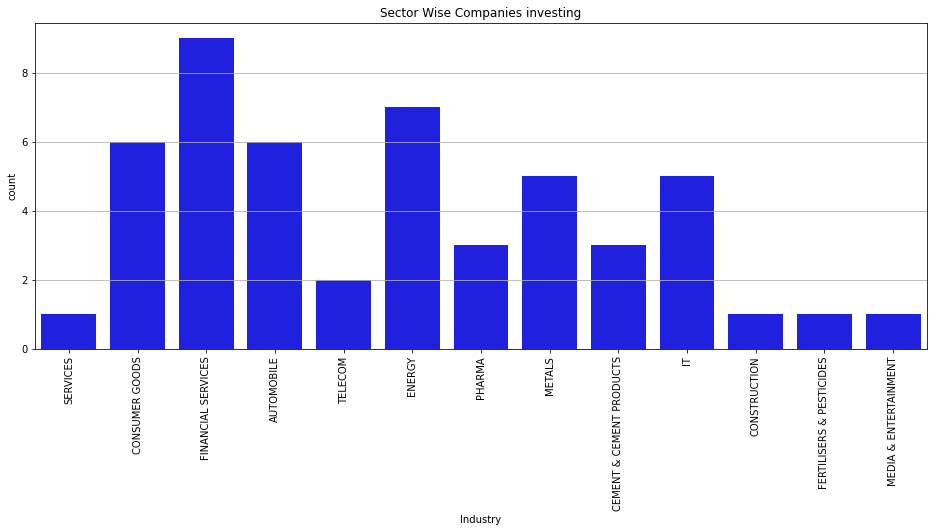

```python
plt.figure(figsize=(16,6))
sns.countplot(metadatas['Industry'],color="b")
plt.title('Sector Wise Companies investing')
plt.xticks(rotation=90)
plt.grid(axis='y')
plt.show()
```

Majority of the sector is Financial Services and Energy sector , Most of the MNC's are investing these two sectors

There are 13 sectors in Nifty-50 Stocks

The top trading companies are listed in Each Sector

So that We have a good understanding idea to invest our money in which sector

### Display industry sectors and Companys

```python
ab=metadatas.iloc[:,[1,0]]
ab.sort_values(by='Industry')
```

|  | Industry | Company Name |
| --- | --- | --- |
| 18 | AUTOMOBILE | Hero MotoCorp Ltd. |
| 30 | AUTOMOBILE | Mahindra & Mahindra Ltd. |
| 31 | AUTOMOBILE | Maruti Suzuki India Ltd. |
| 40 | AUTOMOBILE | Tata Motors Ltd. |
| 12 | AUTOMOBILE | Eicher Motors Ltd. |
| 3 | AUTOMOBILE | Bajaj Auto Ltd. |
| 14 | CEMENT & CEMENT PRODUCTS | Grasim Industries Ltd. |
| 38 | CEMENT & CEMENT PRODUCTS | Shree Cement Ltd. |
| 45 | CEMENT & CEMENT PRODUCTS | UltraTech Cement Ltd. |
| 29 | CONSTRUCTION | Larsen & Toubro Ltd. |
| 26 | CONSUMER GOODS | ITC Ltd. |
| 8 | CONSUMER GOODS | Britannia Industries Ltd. |
| 44 | CONSUMER GOODS | Titan Company Ltd. |
| 32 | CONSUMER GOODS | Nestle India Ltd. |
| 20 | CONSUMER GOODS | Hindustan Unilever Ltd. |
| 1 | CONSUMER GOODS | Asian Paints Ltd. |
| 36 | ENERGY | Reliance Industries Ltd. |
| 33 | ENERGY | NTPC Ltd. |
| 34 | ENERGY | Oil & Natural Gas Corporation Ltd. |
| 13 | ENERGY | GAIL (India) Ltd. |
| 7 | ENERGY | Bharat Petroleum Corporation Ltd. |
| 35 | ENERGY | Power Grid Corporation of India Ltd. |
| 25 | ENERGY | Indian Oil Corporation Ltd. |
| 46 | FERTILISERS & PESTICIDES | UPL Ltd. |
| 28 | FINANCIAL SERVICES | Kotak Mahindra Bank Ltd. |
| 37 | FINANCIAL SERVICES | State Bank of India |
| 22 | FINANCIAL SERVICES | IndusInd Bank Ltd. |
| 21 | FINANCIAL SERVICES | ICICI Bank Ltd. |
| 17 | FINANCIAL SERVICES | HDFC Bank Ltd. |
| 16 | FINANCIAL SERVICES | Housing Development Finance Corporation Ltd. |
| 5 | FINANCIAL SERVICES | Bajaj Finance Ltd. |
| 4 | FINANCIAL SERVICES | Bajaj Finserv Ltd. |
| 2 | FINANCIAL SERVICES | Axis Bank Ltd. |
| 42 | IT | Tata Consultancy Services Ltd. |
| 15 | IT | HCL Technologies Ltd. |
| 43 | IT | Tech Mahindra Ltd. |
| 48 | IT | Wipro Ltd. |
| 24 | IT | Infosys Ltd. |
| 49 | MEDIA & ENTERTAINMENT | Zee Entertainment Enterprises Ltd. |
| 41 | METALS | Tata Steel Ltd. |
| 19 | METALS | Hindalco Industries Ltd. |
| 10 | METALS | Coal India Ltd. |
| 47 | METALS | Vedanta Ltd. |
| 27 | METALS | JSW Steel Ltd. |
| 39 | PHARMA | Sun Pharmaceutical Industries Ltd. |
| 11 | PHARMA | Dr. Reddy's Laboratories Ltd. |
| 9 | PHARMA | Cipla Ltd. |
| 0 | SERVICES | Adani Ports and Special Economic Zone Ltd. |
| 23 | TELECOM | Bharti Infratel Ltd. |
| 6 | TELECOM | Bharti Airtel Ltd. |

### Plot the graph to Visualize the Trending Price of Adani Port Stock

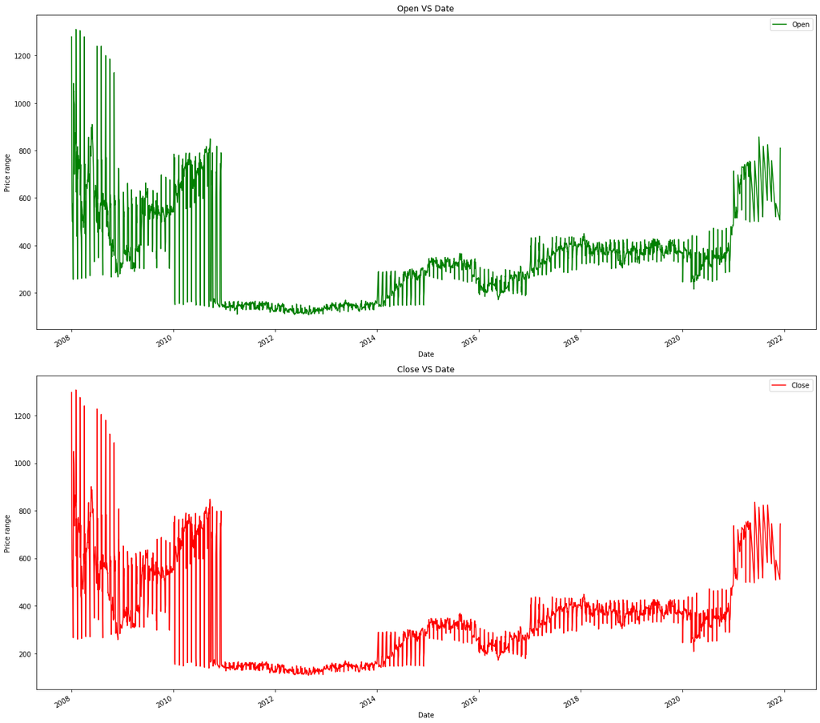

```python
fig, (ax1, ax2) = plt.subplots(nrows=2, ncols=1, figsize=(17,15))

# Plot open price on first subplot
stocks.plot(ax=ax1, x='Date', y='Open', color='g')
ax1.set_xlabel("Date")
ax1.set_ylabel("Price range")
ax1.set_title("Open VS Date")

# Plot close price on second subplot
stocks.plot(ax=ax2, x='Date', y='Close', color='r')
ax2.set_xlabel("Date")
ax2.set_ylabel("Price range")
ax2.set_title("Close VS Date")

plt.tight_layout()
plt.show()
```

### Plot 100 Days moving Average

```python
    #use rolling command into take the 100 days average value
ma100=stocks.Open.rolling(100).mean()
```

```python
#View
ma100
```

```
0            NaN
1            NaN
2            NaN
3            NaN
4            NaN
          ...
3294    602.1925
3295    605.5345
3296    608.9745
3297    612.3565
3298    615.4975
Name: Open, Length: 3299, dtype: float64
```

This is showing first 100 values as NAN values after that it takes the avearage of every 100 to 100.

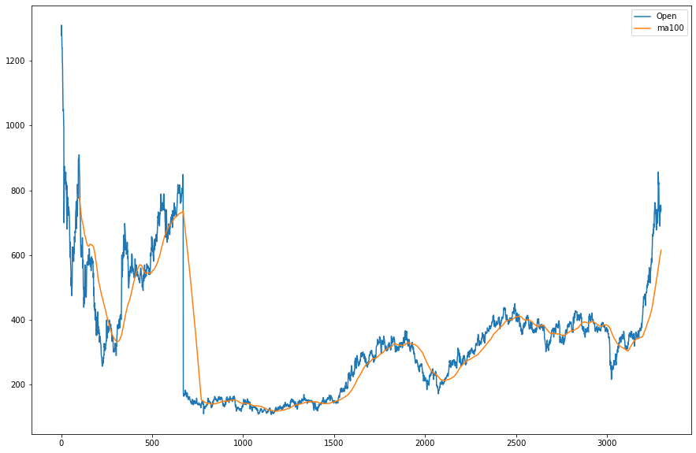

```python
plt.figure(figsize=(15,10))
plt.plot(stocks.Open,label="Open")
plt.plot(ma100,label="ma100")
plt.legend()
plt.show()
```

Importance of a 100-day Moving Average A moving average over 100 days helps investors see how the stock has performed over 20 weeks and to find the price trend if it is upward or downward

### Plot the difference between 100 and 200 Days moving Average

```python
#Plot-the-difference-between-100-and-200-Days-moving-Average
ma200=stocks.Open.rolling(200).mean()
```

```python
#view the data
ma200
```

```
0             NaN
1             NaN
2             NaN
3             NaN
4             NaN
          ...
3294    475.02825
3295    476.95825
3296    479.02825
3297    481.08925
3298    483.10300
Name: Open, Length: 3299, dtype: float64
```

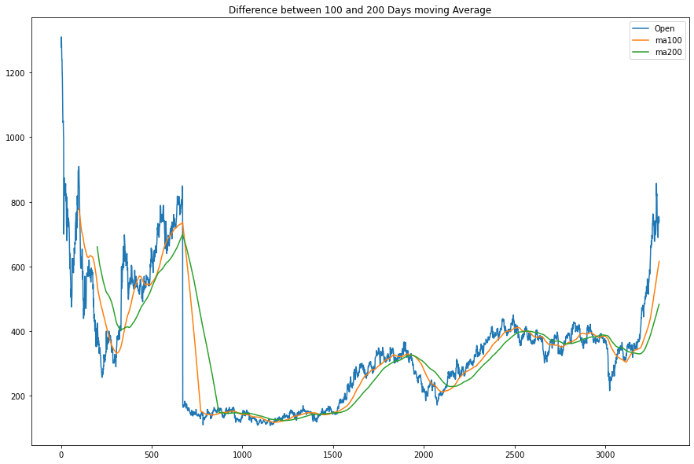

```python
plt.figure(figsize=(15,10))
plt.plot(stocks.Open,label="Open")
plt.plot(ma100,label="ma100")
plt.plot(ma200,label="ma200")
plt.title('Difference between 100 and 200 Days moving Average')
plt.legend()
plt.show()
```

The difference between a 100-day moving average and a 200-day moving average is the amount of data that is being used to calculate the average. Because the 200-day moving average is based on twice as much data as the 100-day moving average, it will be less sensitive to short-term fluctuations and changes in the stock's price. It is considered as a long-term indicator, looking at the average trend of price over a longer period.

```python
#create a Duplicate dataset
stocksdate=stocks
```

```python
#Assign the start date and end date to these variable and access
start_date = "2019-04-30"
end_date = "2021-04-30"
mask=(stocksdate["Date"] >= start_date) & (stocksdate["Date"] <= end_date)
stocksdate=stocksdate.loc[mask]
```

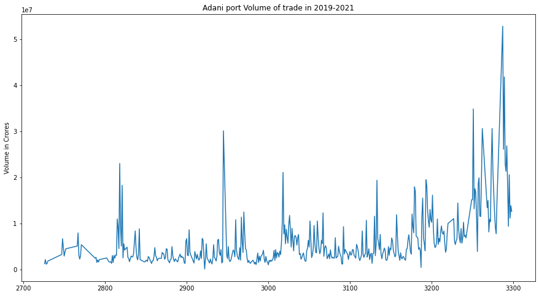

```python
plt.figure(figsize=(15,8))
plt.plot(stocksdate['Volume'])
plt.title("Adani port Volume of trade in 2019-2021")
plt.ylabel('Volume in Crores')
plt.show()
```

```python
max_volume=max(stocksdate['Volume'])
max_row=stocksdate.loc[stocksdate['Volume'] == max_volume]
max_row
```

|  | Date | Symbol | Open | High | Low | Last | Close | VWAP | Volume | Turnover | Deliverable Volume | M.Y |
| --- | --- | --- | --- | --- | --- | --- | --- | --- | --- | --- | --- | --- |
| 3287 | 2021-04-13 | ADANIPORTS | 750.0 | 755.75 | 701.35 | 733.1 | 731.05 | 723.89 | 52812517 | 3.823030e+15 | 8937704 | Apr-21 |

### Find the average of High,Low,Open,Close in 2019-2021

```python
#find the average
avghigh=stocksdate["High"].mean()
avglow=stocksdate["Low"].mean()
avgopen=stocksdate["Open"].mean()
avgclose=stocksdate["Close"].mean()

print("Adani Port Average high:",avghigh,
      "\nAdani Port Average Low:",avglow,
      "\nAdani Port Average Open:",avgopen,
      "\nAdani Port Average Close:",avgclose)
```

```
Adani Port Average high: 403.287421383648
Adani Port Average Low: 389.80922431865855
Adani Port Average Open: 396.83899371069174
Adani Port Average Close: 396.69748427672914
```

### Find the Intraday Volume of Trade Per Day

```python
#To find the intraday volume is to subtract the Volume into Deliverable Volume
stocks["Intraday Volume"]=stocks['Volume']-stocks["Deliverable Volume"]
stocks.head()
```

|  | Date | Symbol | Open | High | Low | Last | Close | VWAP | Volume | Turnover | Deliverable Volume | M.Y | Intraday Volume |
| --- | --- | --- | --- | --- | --- | --- | --- | --- | --- | --- | --- | --- | --- |
| 0 | 2008-01-01 | MUNDRAPORT | 1279.00 | 1319.0 | 1263.70 | 1308.00 | 1296.85 | 1285.72 | 491348 | 6.317350e+13 | 172911 | Jan-08 | 318437 |
| 1 | 2008-02-01 | MUNDRAPORT | 1310.25 | 1324.0 | 1270.00 | 1300.15 | 1307.45 | 1302.15 | 703815 | 9.164730e+13 | 221397 | Jan-08 | 482418 |
| 2 | 2008-03-01 | MUNDRAPORT | 1305.00 | 1314.7 | 1261.15 | 1267.15 | 1275.80 | 1289.24 | 505058 | 6.511430e+13 | 217437 | Jan-08 | 287621 |
| 3 | 2008-04-01 | MUNDRAPORT | 1278.80 | 1294.8 | 1233.00 | 1239.90 | 1240.35 | 1256.03 | 550795 | 6.918170e+13 | 230237 | Jan-08 | 320558 |
| 4 | 2008-07-01 | MUNDRAPORT | 1240.00 | 1278.9 | 1215.00 | 1233.00 | 1227.25 | 1244.76 | 630963 | 7.853980e+13 | 239404 | Jan-08 | 391559 |

In this Process i add one column to find the intraday volume of trade

### Plot Different types of volume trades in adani stocks

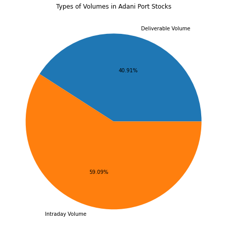

```python
#Plot the Piechart
plt.figure(figsize=(8,8))
DVIV=["Deliverable Volume","Intraday Volume"]
piechart=stocks["Deliverable Volume"].sum(),stocks["Intraday Volume"].sum()
plt.pie(piechart,labels=DVIV,autopct="%1.2f%%")
plt.title("Types of Volumes in Adani Port Stocks")
plt.show()
```

In this Pie chart Display the deliverable volume and intraday volume of trade per day the most of the people are doing intraday trading only, so adani port stock is more volatile so most of all investing intraday Volume

### Top 5 high volume trades in adani stocks

```python
Top_5=stocks.sort_values(by="Volume",ascending=False)
Top_5.head()
```

|  | Date | Symbol | Open | High | Low | Last | Close | VWAP | Volume | Turnover | Deliverable Volume | M.Y | Intraday Volume |
| --- | --- | --- | --- | --- | --- | --- | --- | --- | --- | --- | --- | --- | --- |
| 3283 | 2021-07-04 | ADANIPORTS | 857.0 | 885.00 | 795.00 | 812.45 | 814.75 | 835.16 | 97717880 | 8.160990e+15 | 8025095 | Apr-21 | 89692785 |
| 3282 | 2021-06-04 | ADANIPORTS | 756.0 | 852.70 | 743.00 | 849.85 | 835.55 | 800.35 | 64555516 | 5.166680e+15 | 4484783 | Apr-21 | 60070733 |
| 3287 | 2021-04-13 | ADANIPORTS | 750.0 | 755.75 | 701.35 | 733.10 | 731.05 | 723.89 | 52812517 | 3.823030e+15 | 8937704 | Apr-21 | 43874813 |
| 3289 | 2021-04-16 | ADANIPORTS | 750.9 | 794.85 | 743.00 | 749.15 | 755.50 | 770.01 | 41791181 | 3.217940e+15 | 3455564 | Apr-21 | 38335617 |
| 3251 | 2021-02-17 | ADANIPORTS | 658.0 | 670.00 | 646.90 | 654.00 | 655.75 | 658.20 | 34868085 | 2.295020e+15 | 6455210 | Feb-21 | 28412875 |

### Find the average monthly Open of adani Port

```python
#Assume new Variable
stockdates=stocksdate
stockdates=stockdates.set_index('Date')
stockavg.head()
```

[output not shown]

```python
stockdates.Open.resample("M").mean()
```

```
Date
2019-04-30    391.150000
2019-05-31    384.502174
2019-06-30    397.325000
2019-07-31    390.902381
2019-08-31    366.166667
2019-09-30    384.887500
2019-10-31    400.900000
2019-11-30    375.608696
2019-12-31    373.268421
2020-01-31    371.528261
2020-02-29    363.683333
2020-03-31    294.606522
2020-04-30    301.769048
2020-05-31    322.086842
2020-06-30    346.825000
2020-07-31    329.616667
2020-08-31    352.378571
2020-09-30    347.961364
2020-10-31    359.329545
2020-11-30    371.550000
2020-12-31    424.822500
2021-01-31    549.368750
2021-02-28    654.150000
2021-03-31    700.175000
2021-04-30    709.053333
Freq: M, Name: Open, dtype: float64
```

```python
stockdates1=stockdates.resample("M").last()
stockdates1
```

| Date | Symbol | Open | High | Low | Last | Close | VWAP | Volume | Turnover | Deliverable Volume | M.Y |
| --- | --- | --- | --- | --- | --- | --- | --- | --- | --- | --- | --- |
| 2019-04-30 | ADANIPORTS | 391.15 | 393.95 | 384.80 | 391.70 | 392.80 | 390.32 | 2502107 | 9.766210e+13 | 1548307 | Apr-19 |
| 2019-05-31 | ADANIPORTS | 408.80 | 417.70 | 407.35 | 416.00 | 416.40 | 413.44 | 4217665 | 1.743750e+14 | 1170858 | May-19 |
| 2019-06-30 | ADANIPORTS | 408.70 | 413.35 | 407.00 | 410.20 | 410.20 | 410.39 | 2148799 | 8.818470e+13 | 540507 | Jun-19 |
| 2019-07-31 | ADANIPORTS | 373.00 | 381.80 | 368.65 | 377.60 | 377.55 | 376.37 | 2429787 | 9.144880e+13 | 838299 | Jul-19 |
| 2019-08-31 | ADANIPORTS | 368.45 | 368.85 | 359.40 | 364.20 | 365.70 | 364.29 | 2313806 | 8.428930e+13 | 831576 | Aug-19 |
| 2019-09-30 | ADANIPORTS | 403.00 | 415.55 | 401.45 | 415.00 | 413.95 | 409.91 | 3152658 | 1.292300e+14 | 1649016 | Sep-19 |
| 2019-10-31 | ADANIPORTS | 399.25 | 400.00 | 393.65 | 395.90 | 395.80 | 396.41 | 2529130 | 1.002570e+14 | 1577945 | Oct-19 |
| 2019-11-30 | ADANIPORTS | 372.00 | 384.95 | 370.80 | 381.00 | 382.05 | 379.84 | 30111277 | 1.143740e+15 | 13250688 | Nov-19 |
| 2019-12-31 | ADANIPORTS | 366.00 | 368.65 | 364.90 | 366.20 | 366.00 | 366.52 | 2043206 | 7.488700e+13 | 816396 | Dec-19 |
| 2020-01-31 | ADANIPORTS | 380.05 | 381.55 | 368.25 | 369.55 | 369.40 | 371.94 | 2912256 | 1.083190e+14 | 1073862 | Jan-20 |
| 2020-02-29 | ADANIPORTS | 347.00 | 348.65 | 339.20 | 344.85 | 342.20 | 343.99 | 4299292 | 1.478900e+14 | 2037570 | Feb-20 |
| 2020-03-31 | ADANIPORTS | 255.00 | 259.60 | 247.05 | 250.45 | 251.30 | 253.13 | 6401288 | 1.620360e+14 | 2944373 | Mar-20 |
| 2020-04-30 | ADANIPORTS | 295.05 | 296.00 | 285.10 | 290.65 | 290.10 | 290.10 | 4675412 | 1.356320e+14 | 1277137 | Apr-20 |
| 2020-05-31 | ADANIPORTS | 330.00 | 330.00 | 322.05 | 327.00 | 323.80 | 324.02 | 12299544 | 3.985360e+14 | 8624540 | May-20 |
| 2020-06-30 | ADANIPORTS | 344.00 | 349.80 | 342.40 | 346.10 | 343.90 | 346.62 | 2828820 | 9.805120e+13 | 1229174 | Jun-20 |
| 2020-07-31 | ADANIPORTS | 315.00 | 318.15 | 312.75 | 315.15 | 315.20 | 315.45 | 1945026 | 6.135580e+13 | 249180 | Jul-20 |
| 2020-08-31 | ADANIPORTS | 365.00 | 378.35 | 352.00 | 353.55 | 355.75 | 367.22 | 19379274 | 7.116480e+14 | 2963192 | Aug-20 |
| 2020-09-30 | ADANIPORTS | 340.55 | 346.55 | 330.00 | 344.40 | 341.75 | 338.41 | 2757175 | 9.330570e+13 | 434674 | Sep-20 |
| 2020-10-31 | ADANIPORTS | 345.20 | 362.70 | 343.20 | 358.00 | 359.85 | 357.09 | 12044260 | 4.300860e+14 | 2503788 | Oct-20 |
| 2020-11-30 | ADANIPORTS | 411.00 | 416.00 | 408.20 | 412.00 | 411.55 | 411.67 | 10593353 | 4.360990e+14 | 4012544 | Nov-20 |
| 2020-12-31 | ADANIPORTS | 485.40 | 490.80 | 480.25 | 480.75 | 483.75 | 486.21 | 4386328 | 2.132660e+14 | 833821 | Dec-20 |
| 2021-01-31 | ADANIPORTS | 527.55 | 533.10 | 507.10 | 510.00 | 509.70 | 520.22 | 6781488 | 3.527880e+14 | 1734454 | Jan-21 |
| 2021-02-28 | ADANIPORTS | 697.10 | 703.45 | 668.00 | 668.25 | 675.90 | 686.34 | 19909990 | 1.366510e+15 | 3346842 | Feb-21 |
| 2021-03-31 | ADANIPORTS | 705.00 | 719.90 | 698.60 | 702.40 | 702.40 | 710.23 | 7752226 | 5.505830e+14 | 1464702 | Mar-21 |
| 2021-04-30 | ADANIPORTS | 739.00 | 759.45 | 724.50 | 726.40 | 730.05 | 743.35 | 12600934 | 9.366910e+14 | 3514692 | Apr-21 |

```python
#Find the quarterly date
stockdates1.resample("Q").last()
```

| Date | Symbol | Open | High | Low | Last | Close | VWAP | Volume | Turnover | Deliverable Volume | M.Y |
| --- | --- | --- | --- | --- | --- | --- | --- | --- | --- | --- | --- |
| 2019-06-30 | ADANIPORTS | 408.70 | 413.35 | 407.00 | 410.20 | 410.20 | 410.39 | 2148799 | 8.818470e+13 | 540507 | Jun-19 |
| 2019-09-30 | ADANIPORTS | 403.00 | 415.55 | 401.45 | 415.00 | 413.95 | 409.91 | 3152658 | 1.292300e+14 | 1649016 | Sep-19 |
| 2019-12-31 | ADANIPORTS | 366.00 | 368.65 | 364.90 | 366.20 | 366.00 | 366.52 | 2043206 | 7.488700e+13 | 816396 | Dec-19 |
| 2020-03-31 | ADANIPORTS | 255.00 | 259.60 | 247.05 | 250.45 | 251.30 | 253.13 | 6401288 | 1.620360e+14 | 2944373 | Mar-20 |
| 2020-06-30 | ADANIPORTS | 344.00 | 349.80 | 342.40 | 346.10 | 343.90 | 346.62 | 2828820 | 9.805120e+13 | 1229174 | Jun-20 |
| 2020-09-30 | ADANIPORTS | 340.55 | 346.55 | 330.00 | 344.40 | 341.75 | 338.41 | 2757175 | 9.330570e+13 | 434674 | Sep-20 |
| 2020-12-31 | ADANIPORTS | 485.40 | 490.80 | 480.25 | 480.75 | 483.75 | 486.21 | 4386328 | 2.132660e+14 | 833821 | Dec-20 |
| 2021-03-31 | ADANIPORTS | 705.00 | 719.90 | 698.60 | 702.40 | 702.40 | 710.23 | 7752226 | 5.505830e+14 | 1464702 | Mar-21 |
| 2021-06-30 | ADANIPORTS | 739.00 | 759.45 | 724.50 | 726.40 | 730.05 | 743.35 | 12600934 | 9.366910e+14 | 3514692 | Apr-21 |